# SRM Chapter 5.1

theBudgetActuary

# **Decision Trees**

#### *Supervised/Unsupervised:* **Supervised**

#### *Type of Model:* **Regression and Classification**

#### *Parametric/Non-Parametric:* **Non-Parametric**

#### *Tuning:* **Early Stopping or Cost Complexity Pruning**

# Decision Trees

In this chapter we will focus on decision trees, which is both an easy model to implement and to interpret. Just like KNN, decision trees can be used for both classification and regression problems.

In this section we will cover decision trees for regression, which are simply known as regression trees. Next section we will cover decision trees for classification, known as classification trees. Finally, we will end this chapter by addressing regression and classification trees biggest weakness which is the high variance by building an ensemble of individual trees.

# Regression Trees

Regression trees are a highly interpretable model where no statistical background is required in order to interpret the results.

## Structure of Decision Tree

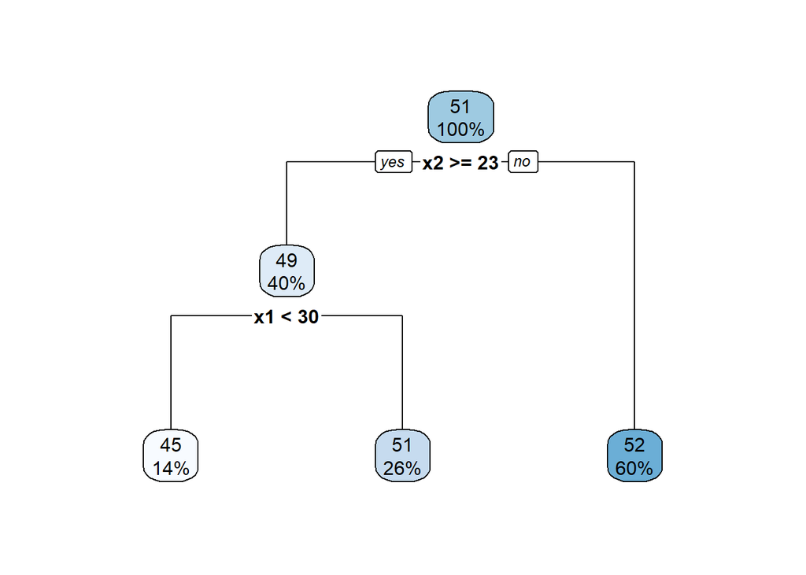

Above are the results from a regression tree. The first split of the decision tree is known as the root node. The following splits are the internal nodes. From the regression tree above there exists two total nodes, the root node and one internal node.

The two lines protruding from each node are called the branches. Each node creates two branches. The base of our regression tree are called leaves. They represent the predictions that that will be made for the different subgroups. The regression tree above has three leaves.

In order to interpret our regression tree above we can say that x2 is the most important predictor. When x2<23 x1 does not have an effect on our output, and our prediction is 52. When x2 $\ge$ 23 the prediction depends on x1. If x1<30 our prediction is 45, else our prediction is 51.

## Making Predictions

In order to make predictions from our regression tree we start at the top and continue until we reach a leaf.

For an example, if we had x1=12 and x2=25 our path would be as follows:

Yes, follow left branch

Is x1<30?

Yes, final prediction: 45

## Creating Splits

The splits are chosen at each node as the partition that will create the largest decrease in the SSE. It will find this value by choosing the midpoint between all consecutive values for the predictors. For instance, if x1 has values 1,2,3,4,5 then the algorithm will try splits at 1.5, 2.5, 3.5, and 4.5. The two subgroups created from these splits are then assigned the mean value for the dependent variable for the observations that fall in that split. This would be done for each predictor.

The goal is to minimize the function:

$\underset{i: x_{i}\in R_{1}(j,s)}{\sum} (y_{i}-\hat{y}_{R_{1}})^{2}\ +\underset{i: x_{i}\in R_{2}(j,s)}{\sum} (y_{i}-\hat{y}_{R_{2}})^{2}$

Decision trees choose the split that minimizes the SSE at the current node. Since it does not consider future nodes at the time of a split it is known as a greedy algorithm, meaning it will not always arrive at the best possible splits as a whole in order to minimize the SSE. For instance, choosing a sub-optimal split at one node might lead to a better split later on and better tree overall. (James et al.)

For categorical predictors the possible splits are set to the possible values of the independent variable. For instance, if the predictor colors has options “orange”, “red”, and “yellow”, the possible left side of the splits would be color=orange, color=red, or color=yellow. Then the right side of the splits would be color$\ne$orange, color$\ne$red, and color$\ne$yellow.

## Pruning

If we wanted to we could partition a tree in way that we ultimately end up with just as many leaves as we have observations. This would mean that our train SSE would be 0 as every prediction would be guessed perfectly. This is obviously a case of over fitting. Generally, there is some kind of stopping mechanism to stop the tree from creating partitions such as the decrease in the SSE must be over a certain amount for a new partition to occur. This is known as early stopping.

The problem with early stopping is that a partition that creates a small decrease in the SSE might lead to a partition that creates a large decrease in the SSE. Generally, it is better to build a larger tree and then use a pruning technique. (James et al.)

Cost Complexity Pruning uses a tuning parameter, $\alpha$, in order to create subtrees of our decision tree. Cost complexity pruning adds a complexity penalty that penalizes trees based off their size. Alpha can take any value from 0 to infinity. As we increase the value of alpha the size of our tree will shrink. When alpha is zero it means no pruning will take place and the decision tree will remain the same.

The formula for Cost Complexity Pruning:

$\underset{m=1}{\overset{|T|}{\sum}} \underset{i:x_{i}\in R_{m}}{\sum} (y_{i}-\hat{y}_{R_{m}})^{2}+a|T|$

In order to choose our value of $\alpha$ we would solve for it like any other tuning parameter, which is to use cross validation. By trying different values of $\alpha$ we will in turn try different subtrees of our original regression tree and see how they perform on data not used to train the model. The alpha value that creates the smallest MSE will be chosen. Then, a new decision tree can be formed using all the data and that value of alpha for the final output. (James et al.)

## Transformations

Decision trees are so easy to implement because they require generally no pre-processing. With linear regression we learned that we must create dummy variables for our categorical predictors and at times use different standardization techniques.

For decision trees no pre-processing is required on our independent variables. This means categorical variables can remain categorical and there is no need to apply standardization techniques as our output would remain exactly the same.

However, if were to apply a log transformation to our dependent variable the results would change and create different partitions. The leaf values would now be in log form so in order to make predictions in the original format, an e terms must be used.

Example:

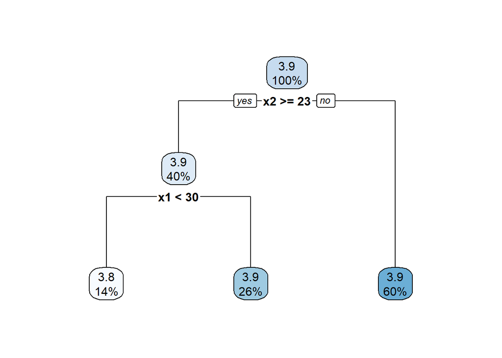

This was the exact same data used in the decision tree earlier, the only difference is the output is now in log form. The predicted value in the original format of an observation with an x2 value of 10 would be $\exp^{3.9}$ = 49.4.

#### Sources:

James, G., Witten, D., Hastie, T., & Tibshirani, R. (n.d.). An introduction to statistical learning: With applications in R.